# Transportation Operator Committee HHTS 2021 notes

https://www.psrc.org/committee/transportation-operators-committee

July 27 meeting

We are gathering materials information that could be useful to the transportation operators committee

```r
library(psrc.travelsurvey)
library(dplyr)
```

```r
library(stringr)
library(ggplot2)
library(psrcplot)
library(forcats)
library(odbc)
library(DBI)
library(tidyr)
```

```r
factor_variable_column <- function(var, table) {
  # This function will mutate a variable in a dataframe into a factor and set levels for ordering

  # read values_metadata table & extract levels column as vector
  levels_col <- vars_meta %>%
     filter(variable == var & survey_year == 2021) %>%
     pull(levels) %>%
     strsplit("\\|") %>%
     unlist()

   # if levels don't exist in vars_meta, use the ones below
   if(is.null(levels_col) | var == 'race_eth_broad') {
      if(var == 'race_eth_broad') {
        l <- c('Asian only, non-Hispanic/Latinx',
               'Black or African American only, non-Hispanic/Latinx',
               'White only, non-Hispanic/Latinx',
               'Other race, including multi-race non-Hispanic',
               'Hispanic or Latinx',
               'No Answer')
      } else if(var == 'hhincome_100') {
       l <- c("Under $25,000", "$25,000-$49,999", "$50,000-$74,999", "$75,000-$99,999", "$100,000 or more", "Prefer not to answer")
     } else if(var == 'edu_simple') {
       l <- c("Less than Bachelors degree", "Bachelors or higher" )
     } else if(var == 'hhsize_simple') {
       l <- c("1 person", "2 people", "3 people", "4 or more people")
     } else if(var == 'NoVehicles') {
       l <- c("No Vehicles", "Has Vehicles")
     } else if (var == 'age_grp') {
       l <- c("18-24 years", "25-34 years", "35-44 years","45-54 years", "55-64 years","65-74 years","75 years or older")
     } else if (var == 'gender_grp') {
       l <- c("Female","Male","Non-binary, another, not listed/prefer not to answer", "Non-binary, another, prefer not to answer", "Not listed here / prefer not to answer")
     } else if (var == 'work_purpose') {
       l <- c("Not Work", "Work")
     }
   } else {
     # extract levels that match the order that is in transit_summs
     l <- intersect(levels_col, unique(table[[var]]))
   }

   # factor column using levels from variable metadata table
   df <- table %>% mutate(!!var := factor(.data[[var]], levels = l))
}
```

```r
# connect to Elmer
db.connect <- function(adatabase) {
  elmer_connection <- dbConnect(odbc(),
                                driver = "SQL Server",
                                server = "AWS-PROD-SQL\\SOCKEYE",
                                database = adatabase,
                                trusted_connection = "yes"
  )
}

# read table
read.dt <- function(adatabase, atable) {
  elmer_connection <- db.connect(adatabase)
  dtelm <- dbReadTable(elmer_connection, SQL(atable))
  dbDisconnect(elmer_connection)
  return(dtelm)
}

# read-in variable metadata table for levels
vars_meta <- read.dt('Elmer', 'HHSurvey.variable_metadata')
```

Ashley Asmus presentation by Met Council on their 2022 transit on-board survey provides a lot of inspiration

https://metrocouncil.org/Council-Meetings/Committees/Transportation-Committee/2022/March-28,-2022/info-1_TransitOnBoardSurvey_2022-03-28.aspx

- Estimate of total transit trips regionally in 2019 vs 2021
- by access mode
- by geography?
- by income group
- by trip purpose
- by time of day
- by race category
- by age category
- by lifecycle
- by gender
- by worker status
- Overall mode share shift in 2019 vs 2021
- by access mode
- by geography?
- by income group
- by trip purpose
- by time of day
- by race category
- by age category
- by gender
- trip_length
- commute_mode_pre_covid vs commute_mode
- by income, race, age, gender
- commute_freq_pre_covid vs commute_freq
  - by income, race, age, gender
- telecommute_freq_pre_covid vs telecommute_freq
  - by income, race, age, gender

Pull in data that might be useful

Origin County and Destination County are missing Home County appears like it may not be filled in everywhere for 2021?

```r
mode_vars<-c('mode_1', 'mode_simple')
other_vars<-c('final_home_rgcnum', 'hhsize', 'vehicle_count',  "hhincome_broad", 'rent_own', 'res_dur', 'student', 'education',  'hhincome_detailed', "age", "age_category", 'race_category', 'race_eth_broad', 'gender', 'employment',  'lifecycle', 'mode_acc', 'dest_purpose_cat')
trip_path_dist<-'trip_path_distance'
all_vars<-c(mode_vars, other_vars, trip_path_dist)
```

```r
transit_data_17_19<- get_hhts("2017_2019", "t", vars=all_vars)%>% mutate(year=ifelse(survey=='2017_2019', '2017/2019', '2021'))
```

```r
transit_data_21<- get_hhts("2021", "t", vars=all_vars)%>% mutate(year=ifelse(survey=='2017_2019', '2017/2019', '2021'))
```

Start simple - What was the total estimated transit trips in 2017/2019 vs 2021?

These are trips made by adults only

```r
trips_by_mode_17_19<-hhts_count(transit_data_17_19, group_vars='mode_simple')%>%
  filter(mode_simple!='Total')
trips_by_mode_21<-hhts_count(transit_data_21, group_vars='mode_simple')%>%filter(mode_simple!='Total')

trips_by_mode_17_19_21<-merge(trips_by_mode_17_19, trips_by_mode_21, by='mode_simple', suffixes=c('17_19', '21'))
trips_by_mode<-rbind(trips_by_mode_17_19, trips_by_mode_21)%>% mutate(year=ifelse(survey=='2017_2019', '2017/2019', '2021'))
```

```r
write.csv(trips_by_mode, 'trips_by_mode.csv')
```

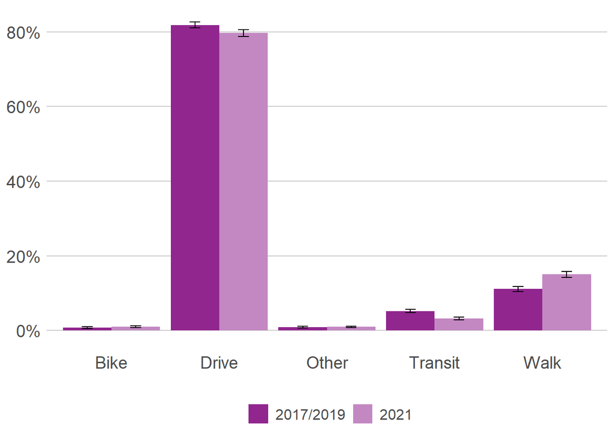

```r
p<-create_bar_chart(t=trips_by_mode, w.x='mode_simple', w.y='share', f='year', w.moe='share_moe', est.type='percent', w.color = 'psrc_pairs')




print(p)
```

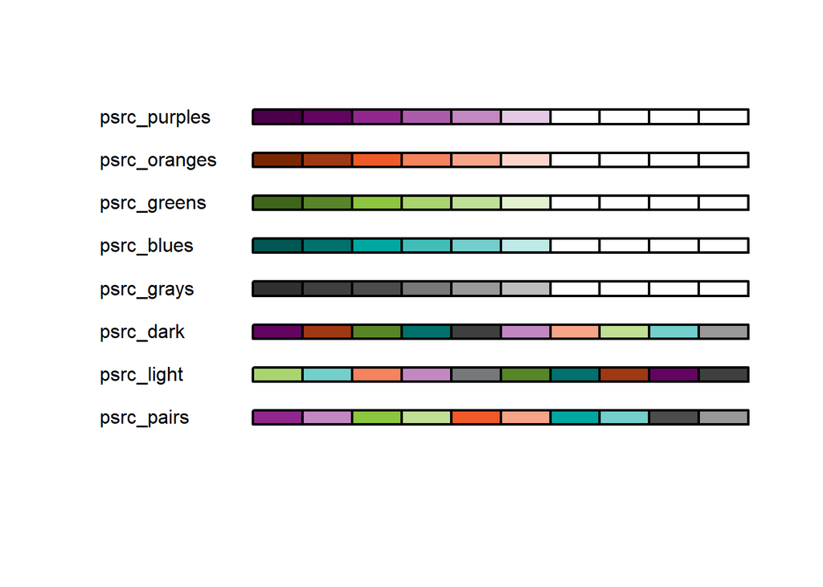

```r
psrc_print_palette()
```

From 2017/2019 to 2021, the transit share went down, drive shares went down, and walking shares went up.

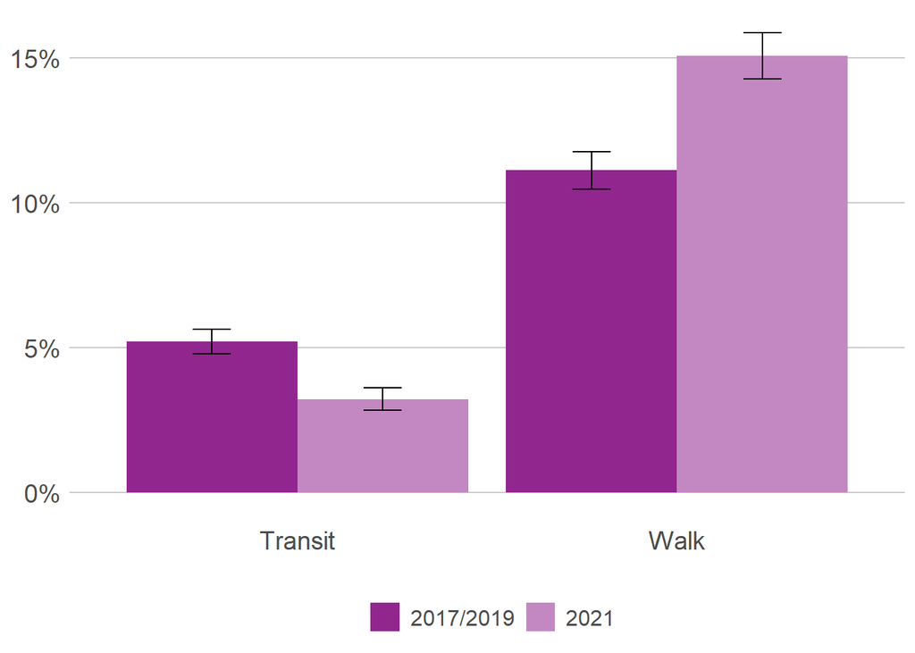

```r
trips_by_mode_no_drive<-trips_by_mode%>%filter(!mode_simple %in% c('Drive', 'Bike', 'Other'))
p<-create_bar_chart(t=trips_by_mode_no_drive, w.x='mode_simple', w.y='share', f='year', w.moe='share_moe', est.type='percent', w.color = 'psrc_pairs')


print(p)
```

```r
transit_modes<-c('Vanpool', 'Bus (public transit)',  'School bus', 'Private bus or shuttle', 'Paratransit', 'Other bus (rMove only)', 'Ferry or water taxi', 'Commuter rail (Sounder, Amtrak)', 'Other rail (e.g., streetcar)', 'Urban Rail (e.g., Link light rail, monorail)', 'Urban Rail (e.g., Link light rail, monorail, streetcar)')
```

```r
transit_data_17_19_only<- get_hhts("2017_2019", "t", vars=all_vars)%>%filter(mode_1 %in% transit_modes)%>%mutate(BusorNot=ifelse(mode_1=='Bus (public transit)', 'Bus', 'Other Transit, not Bus'))
```

```r
transit_data_21_only<- get_hhts("2021", "t", vars=all_vars)%>%filter(mode_1 %in% transit_modes)%>%mutate(BusorNot=ifelse(mode_1=='Bus (public transit)', 'Bus', 'Other Transit, not Bus'))
```

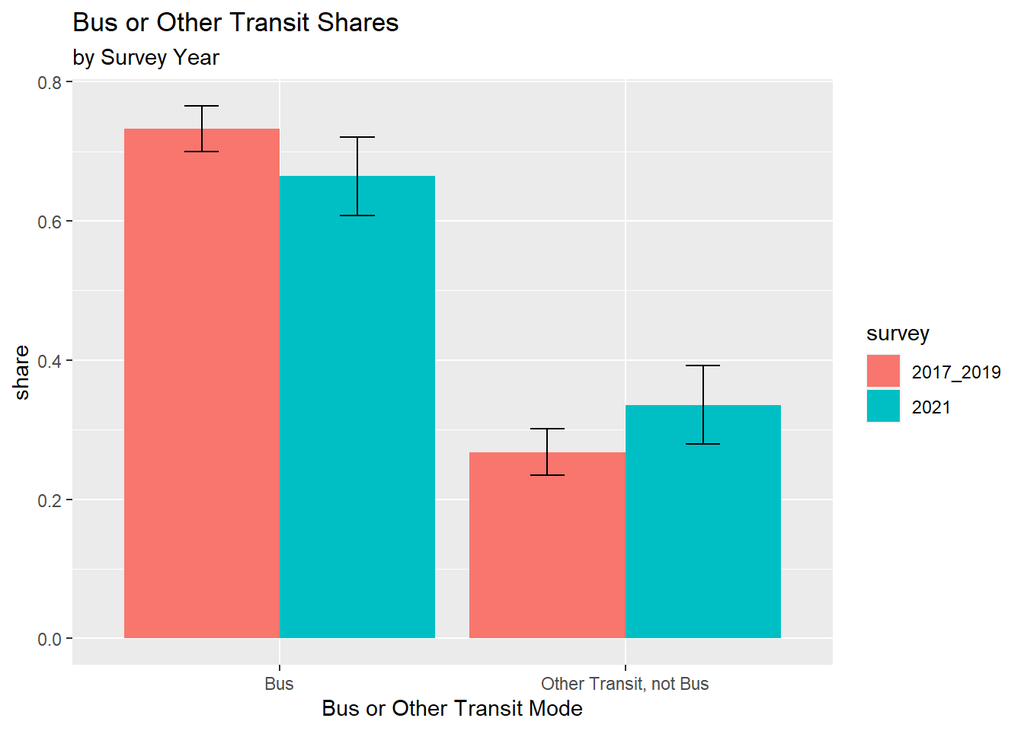

```r
detailed_trips_by_mode_17_19<-hhts_count(transit_data_17_19_only, group_vars='BusorNot', spec_wgt='trip_weight_2017_2019_v2021_adult')%>%filter(BusorNot!='Total')
detailed_trips_by_mode_21<-hhts_count(transit_data_21_only, group_vars='BusorNot', spec_wgt='trip_weight_2021_ABS_Panel_adult')%>%filter(BusorNot!='Total')
detailed_trips_by_mode<- rbind(detailed_trips_by_mode_17_19,detailed_trips_by_mode_21)
p<-ggplot(detailed_trips_by_mode, aes(x=BusorNot, y=share, fill=survey))+geom_bar(stat="identity", position=position_dodge())+xlab('Bus or Other Transit Mode')+ggtitle('Bus or Other Transit Shares', 'by Survey Year')+
  geom_errorbar(aes(ymin=share-share_moe, ymax=share+share_moe), width=.2,
                 position=position_dodge(.9))

print(p)
```

Mode Share by different characteristics

[figure not shown]

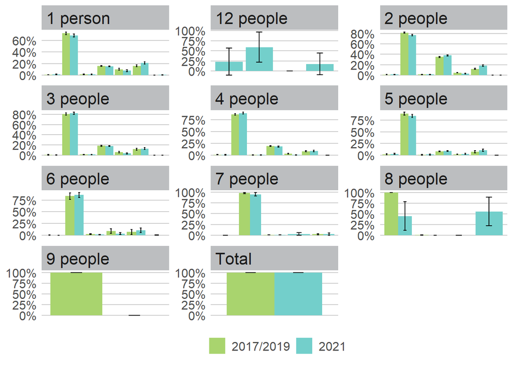

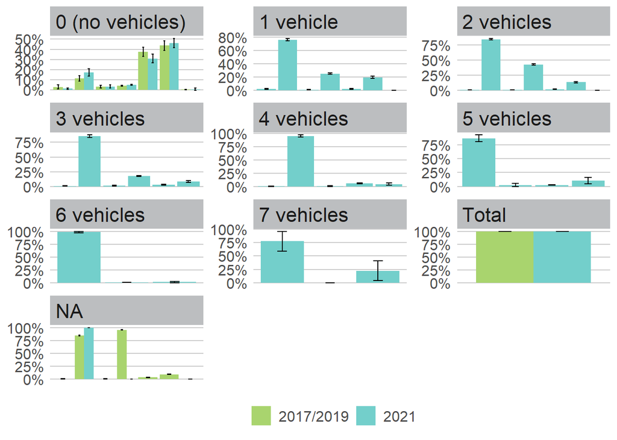

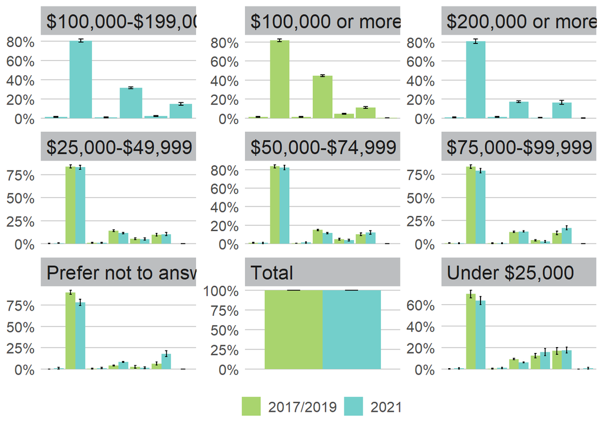

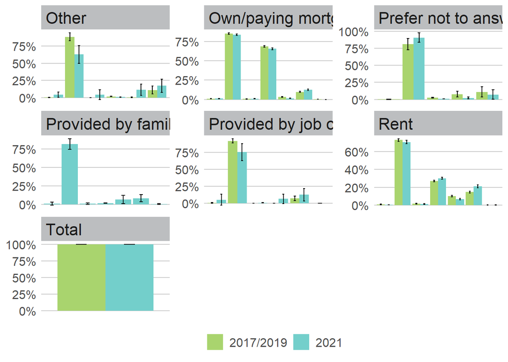

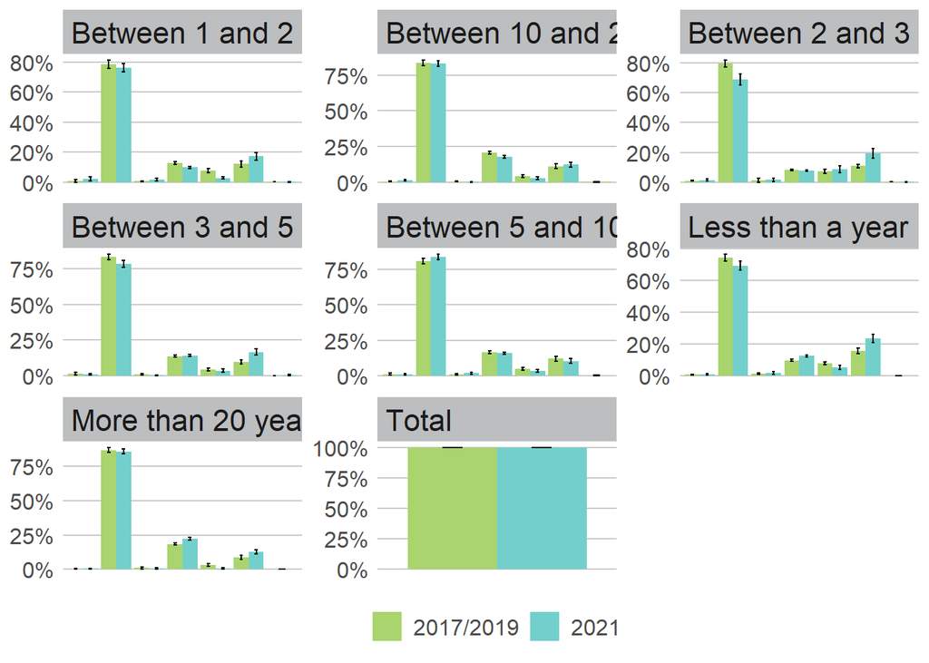

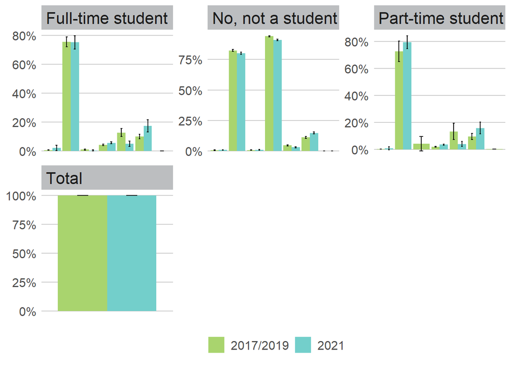

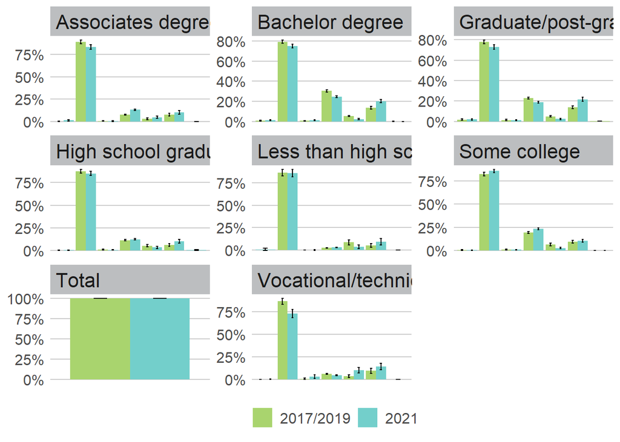

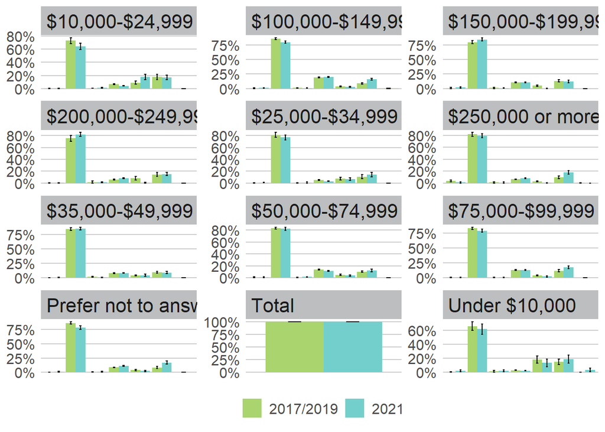

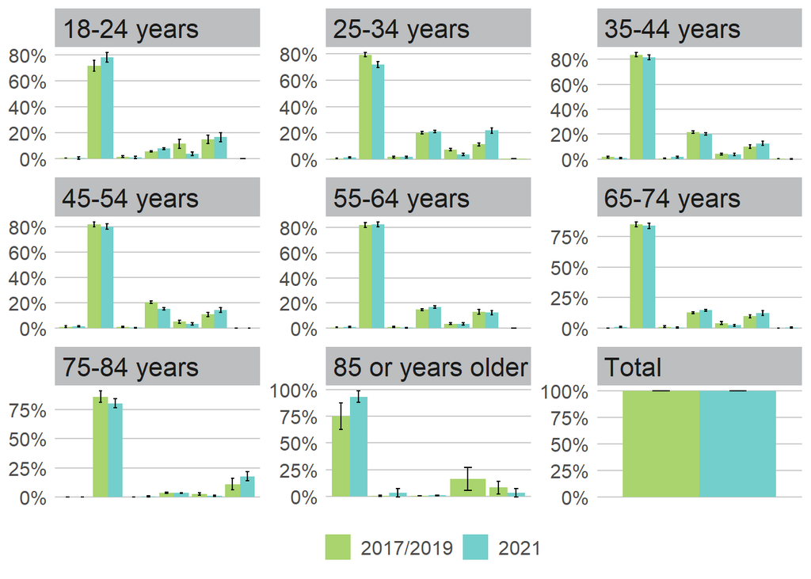

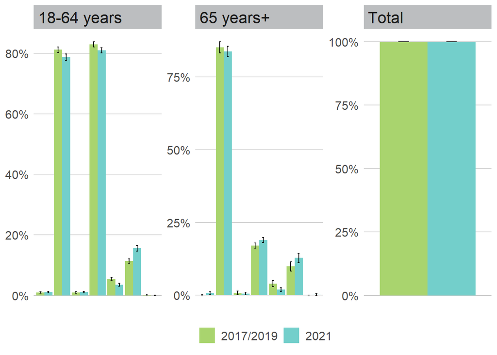

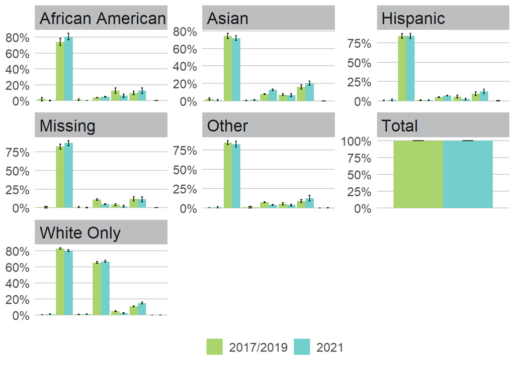

[6 more figures not shown]

```r
groupings<- other_vars
for(g in groupings){

cat_name<- eval(g)

mode_summs_2017_2019<-hhts_count(transit_data_17_19, group_vars=c(g,'mode_simple'), spec_wgt='trip_weight_2017_2019_v2021_adult')%>%
  filter(cat_name!='Total')

mode_summs_2021<-hhts_count(transit_data_21, group_vars=c(g,'mode_simple'), spec_wgt='trip_weight_2021_ABS_Panel_adult')%>%
  filter(cat_name!='Total')

#mode_summs<-merge(mode_summs_2017_2019, mode_summs_2021, by=cat_name, suffixes=c('17_19', '21'))

mode_summs_long<- rbind(mode_summs_2017_2019, mode_summs_2021)%>% mutate(year=ifelse(survey=='2017_2019', '2017/2019', '2021'))

p<-create_facet_bar_chart(mode_summs_long, w.x='mode_simple', w.y='share', f='year', g=cat_name,w.color = 'psrc_light', w.moe='share_moe')

print(p)
}
```

findings: people with zero cars kept using transit more people in smaller households? lower income

first doing detailed groupings, to figure out how to group the data

```
##                   final_home_rgcnum survey17_19 mode_simple17_19   count17_19
##  1:                            <NA>   2017_2019          Transit 588322.69824
##  2:                       Bremerton   2017_2019          Transit     28.15142
##  3:                         Everett   2017_2019          Transit   7425.70840
##  4:                          SeaTac   2017_2019          Transit   1483.02923
##  5:                Seattle Downtown   2017_2019          Transit  26484.38036
##  6: Seattle First Hill/Capitol Hill   2017_2019          Transit  28590.54346
##  7:               Seattle Northgate   2017_2019          Transit   5094.43062
##  8:        Seattle South Lake Union   2017_2019          Transit   4519.73890
##  9:    Seattle University Community   2017_2019          Transit  16041.97625
## 10:                  Seattle Uptown   2017_2019          Transit   9779.75564
## 11:                 Tacoma Downtown   2017_2019          Transit   2390.76151
##     count_moe17_19   share17_19 share_moe17_19 sample_size17_19 survey21
##  1:    57133.03271 0.0468775552   0.0045039324             4423     2021
##  2:       32.74521 0.0005429816   0.0006583836                2     2021
```

[output cut: 21 more lines]

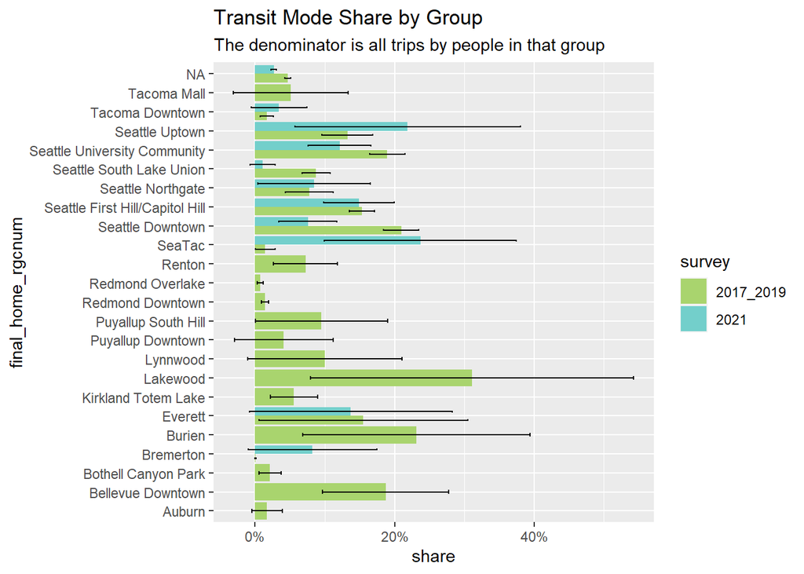

```
##      hhsize survey17_19 mode_simple17_19 count17_19 count_moe17_19 share17_19
## 1: 1 person   2017_2019          Transit  215564.56      34773.555 0.10026018
## 2: 2 people   2017_2019          Transit  216121.37      20382.462 0.04469306
## 3: 3 people   2017_2019          Transit  146764.68      33746.552 0.05807817
## 4: 4 people   2017_2019          Transit   91131.72      19231.566 0.03435120
## 5: 5 people   2017_2019          Transit   19325.83       6574.671 0.01718612
## 6: 6 people   2017_2019          Transit   31515.93      17678.898 0.08895027
##    share_moe17_19 sample_size17_19 survey21 mode_simple21    count21
## 1:    0.015423323             2923     2021       Transit 159761.821
## 2:    0.004374174             3692     2021       Transit 142336.357
## 3:    0.012973474              822     2021       Transit  87884.269
## 4:    0.007238495              410     2021       Transit  16437.682
## 5:    0.006006880               64     2021       Transit  28265.399
## 6:    0.047726928               41     2021       Transit   7312.074
##    count_moe21     share21 share_moe21 sample_size21
## 1:   33054.795 0.076148957 0.015131039           171
## 2:   27823.304 0.027026339 0.005250114           158
## 3:   25754.386 0.035605101 0.010272021            65
## 4:   10228.140 0.006494186 0.004034083            15
## 5:   16056.021 0.023275129 0.013063965            15
## 6:    4306.663 0.035548568 0.021121521            10
```

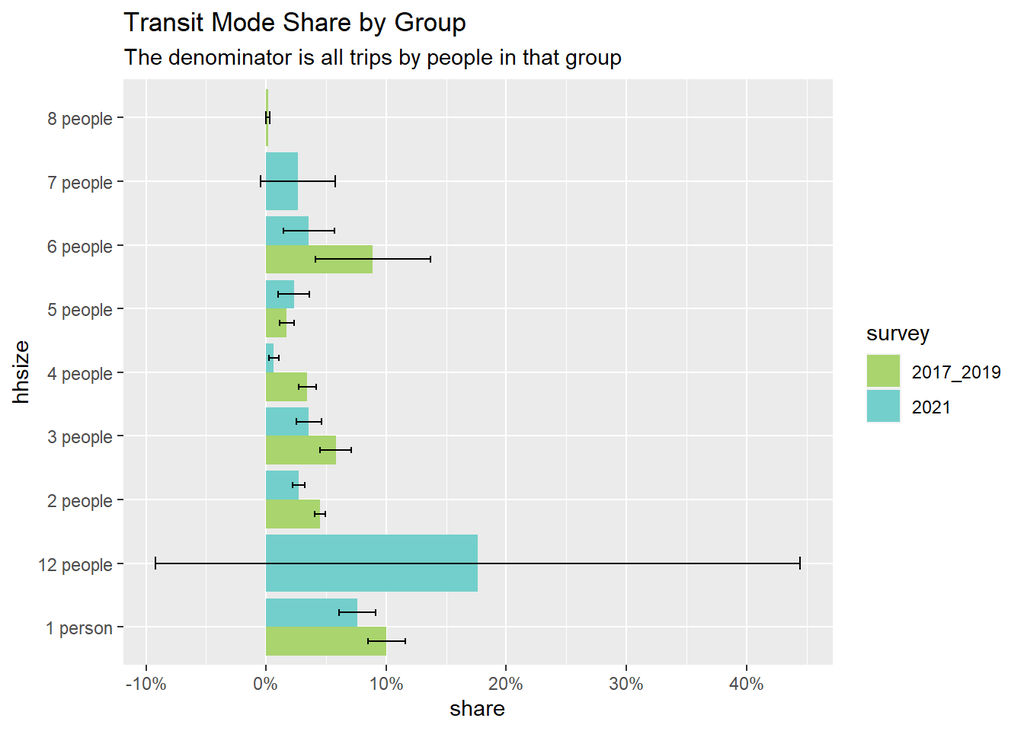

```
##      vehicle_count survey17_19 mode_simple17_19 count17_19 count_moe17_19
## 1: 0 (no vehicles)   2017_2019          Transit     222473       34969.65
##    share17_19 share_moe17_19 sample_size17_19 survey21 mode_simple21  count21
## 1:  0.3772547     0.04566877             2770     2021       Transit 228986.9
##    count_moe21   share21 share_moe21 sample_size21
## 1:    40167.46 0.3096815  0.04410616           214
```

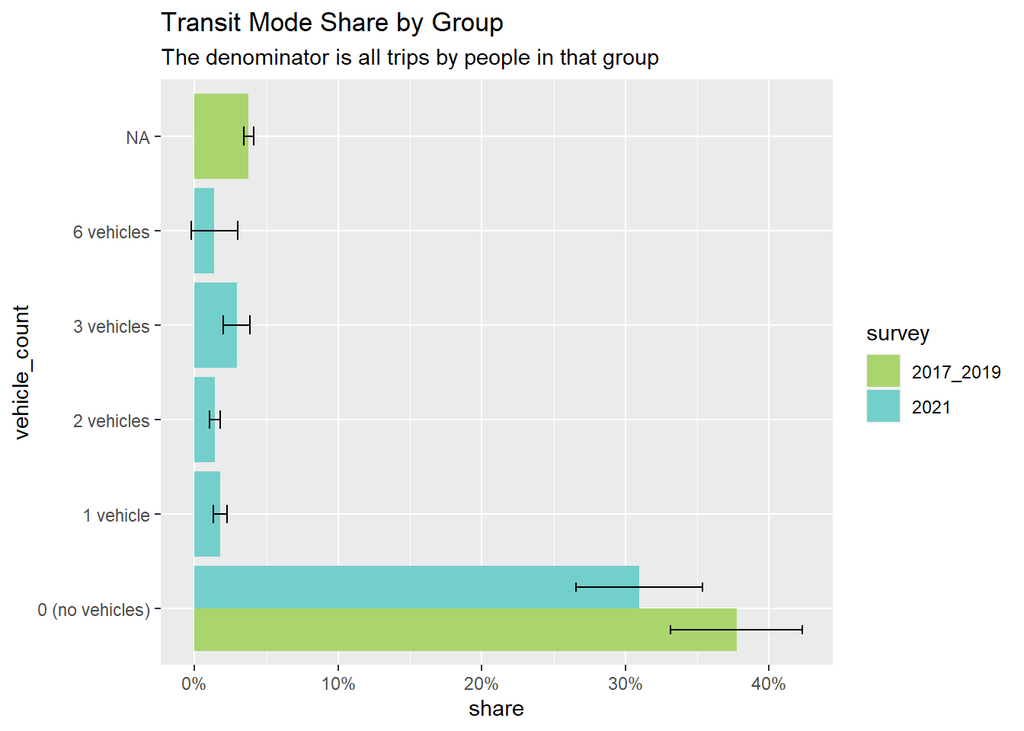

```
##          hhincome_broad survey17_19 mode_simple17_19 count17_19 count_moe17_19
## 1:      $25,000-$49,999   2017_2019          Transit  102906.32      21207.317
## 2:      $50,000-$74,999   2017_2019          Transit   97240.52      19648.852
## 3:      $75,000-$99,999   2017_2019          Transit   65389.68      14796.637
## 4: Prefer not to answer   2017_2019          Transit   16585.24       9033.632
## 5:        Under $25,000   2017_2019          Transit  161383.34      29338.562
##    share17_19 share_moe17_19 sample_size17_19 survey21 mode_simple21   count21
## 1: 0.05270325    0.010849686             1221     2021       Transit  80146.60
## 2: 0.04755168    0.009495902             1061     2021       Transit  61012.84
## 3: 0.03691800    0.008354304              952     2021       Transit  47039.73
## 4: 0.02784839    0.015066002              352     2021       Transit  17818.85
## 5: 0.12494709    0.022014629              919     2021       Transit 139701.19
##    count_moe21    share21 share_moe21 sample_size21
## 1:    20977.65 0.05007746  0.01287648           107
## 2:    17762.30 0.03848689  0.01106552            68
## 3:    18744.56 0.02567913  0.01010542            32
## 4:    12234.89 0.01496594  0.01020290            16
## 5:    31994.07 0.15781391  0.03244817           127
```

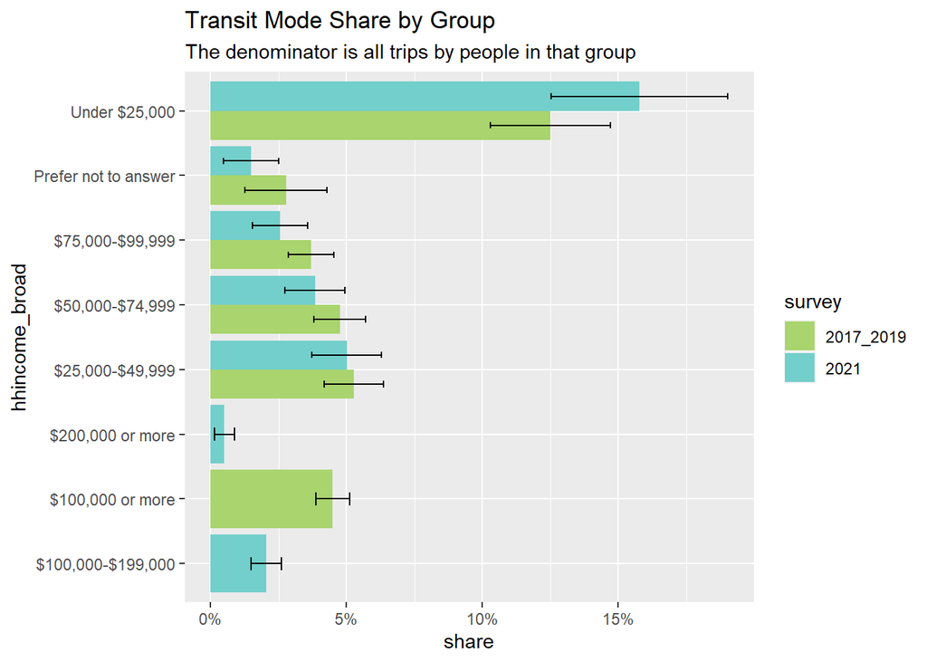

```
##                       rent_own survey17_19 mode_simple17_19   count17_19
## 1:                       Other   2017_2019          Transit   1170.57921
## 2:         Own/paying mortgage   2017_2019          Transit 318141.52993
## 3:        Prefer not to answer   2017_2019          Transit  25625.12293
## 4: Provided by job or military   2017_2019          Transit     97.22453
## 5:                        Rent   2017_2019          Transit 375529.23948
##    count_moe17_19  share17_19 share_moe17_19 sample_size17_19 survey21
## 1:      861.21729 0.004945421    0.003776157               40     2021
## 2:    42423.21494 0.033541635    0.004432097             2863     2021
## 3:    13476.80085 0.078070208    0.041022118               67     2021
## 4:       38.84309 0.002815894    0.001307513               21     2021
## 5:    38756.92524 0.100486668    0.010135041             4964     2021
##    mode_simple21    count21 count_moe21    share21 share_moe21 sample_size21
## 1:       Transit  11619.516    8760.165 0.11434923 0.081656409            10
## 2:       Transit 127742.848   29619.293 0.01401930 0.003238851           103
## 3:       Transit   2646.172    1789.331 0.02181226 0.015283371             6
## 4:       Transit   7942.730    8347.610 0.06542487 0.066766824             5
## 5:       Transit 280563.758   41469.553 0.06732746 0.009691110           308
```

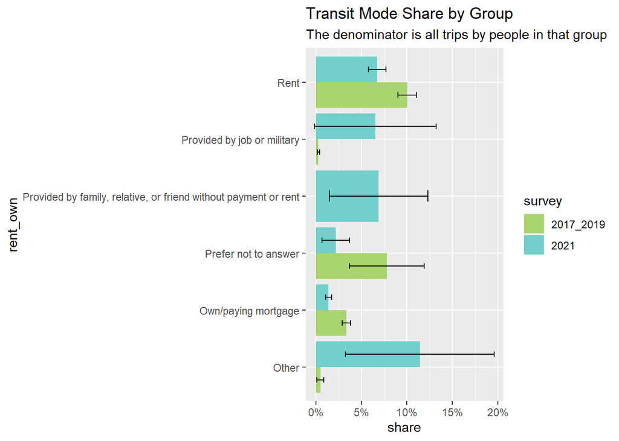

```
##                    res_dur survey17_19 mode_simple17_19 count17_19
## 1:   Between 1 and 2 years   2017_2019          Transit  131316.21
## 2: Between 10 and 20 years   2017_2019          Transit  124467.26
## 3:   Between 2 and 3 years   2017_2019          Transit   83304.29
## 4:   Between 3 and 5 years   2017_2019          Transit   84400.98
## 5:  Between 5 and 10 years   2017_2019          Transit  114004.92
## 6:        Less than a year   2017_2019          Transit  104838.05
## 7:      More than 20 years   2017_2019          Transit   78231.99
##    count_moe17_19 share17_19 share_moe17_19 sample_size17_19 survey21
## 1:       24454.88 0.07473662    0.013861589             1372     2021
## 2:       29924.43 0.04341866    0.010260993              783     2021
## 3:       14332.91 0.07363598    0.012773803             1067     2021
## 4:       19072.88 0.04483532    0.010068714             1231     2021
## 5:       19642.28 0.04975404    0.008677531             1132     2021
## 6:       12508.79 0.07807019    0.009746797             2023     2021
## 7:       29767.05 0.03068157    0.011436157              347     2021
##    mode_simple21  count21 count_moe21     share21 share_moe21 sample_size21
## 1:       Transit 36089.80    8386.564 0.026380292 0.006261747            65
## 2:       Transit 70800.17   22733.628 0.028602234 0.009071091            65
## 3:       Transit 92997.11   26101.203 0.086538666 0.023184312            84
## 4:       Transit 67252.93   22814.119 0.034087420 0.011373616            45
## 5:       Transit 74348.37   21954.908 0.033808062 0.009866956            82
## 6:       Transit 87880.66   24419.144 0.050852390 0.013790995            76
## 7:       Transit 18941.26   10476.437 0.006182414 0.003414460            20
```

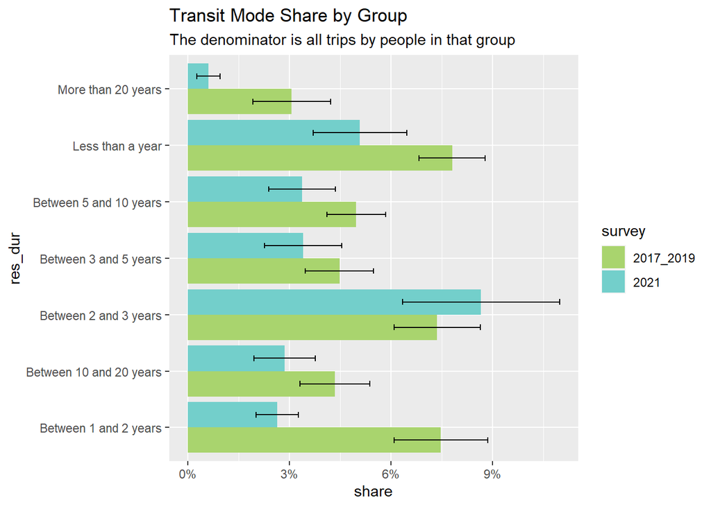

```
##              student survey17_19 mode_simple17_19 count17_19 count_moe17_19
## 1: Full-time student   2017_2019          Transit   74897.87       16526.54
## 2: No, not a student   2017_2019          Transit  611704.09       54024.40
## 3: Part-time student   2017_2019          Transit   33961.74       16932.30
##    share17_19 share_moe17_19 sample_size17_19 survey21 mode_simple21   count21
## 1: 0.12752609    0.027832161              769     2021       Transit  38759.70
## 2: 0.04713193    0.004133115             6931     2021       Transit 390432.56
## 3: 0.13283168    0.061542203              255     2021       Transit  19118.04
##    count_moe21    share21 share_moe21 sample_size21
## 1:    14523.91 0.04969353 0.018484204            35
## 2:    51614.29 0.03093372 0.004059958           379
## 3:     8429.10 0.03979281 0.017586344            23
```

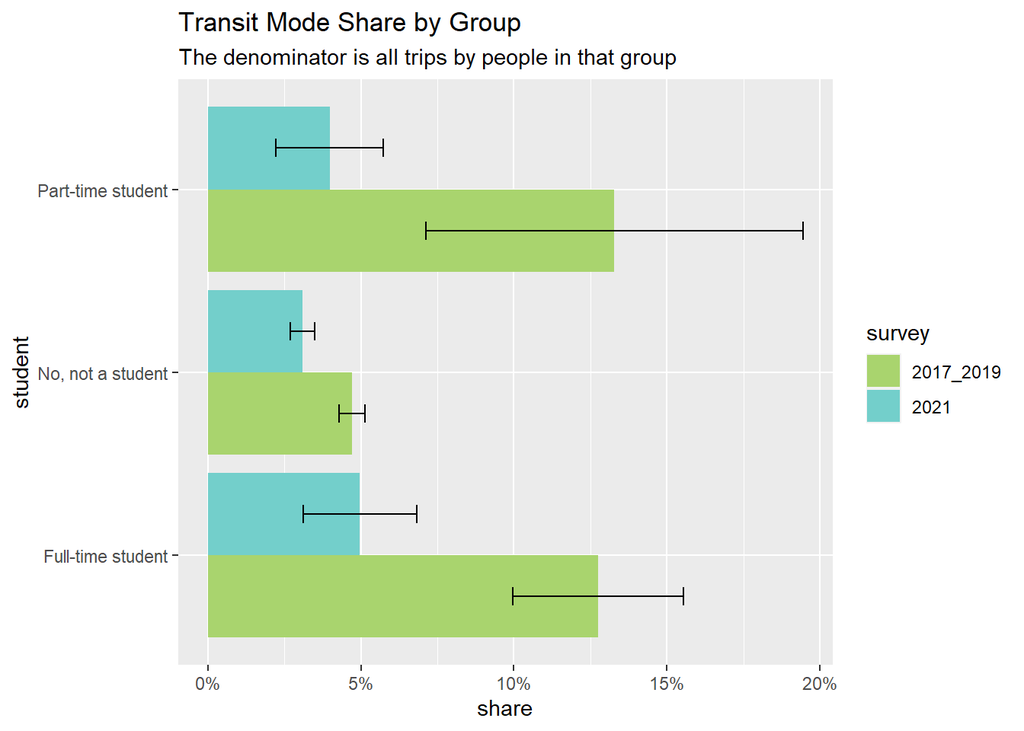

```
##                        education survey17_19 mode_simple17_19 count17_19
## 1:             Associates degree   2017_2019          Transit   29293.49
## 2:               Bachelor degree   2017_2019          Transit  222448.53
## 3: Graduate/post-graduate degree   2017_2019          Transit  158306.81
## 4:          High school graduate   2017_2019          Transit   79975.42
## 5:         Less than high school   2017_2019          Transit   31257.80
## 6:                  Some college   2017_2019          Transit  170301.83
## 7: Vocational/technical training   2017_2019          Transit   28979.83
##    count_moe17_19 share17_19 share_moe17_19 sample_size17_19 survey21
## 1:       9585.237 0.02870666    0.009398056              314     2021
## 2:      24519.838 0.05294035    0.005945088             3675     2021
## 3:      25242.205 0.04992127    0.007902586             2748     2021
## 4:      20736.874 0.05102652    0.013106400              293     2021
## 5:       9620.369 0.08704455    0.027712307               80     2021
## 6:      38186.407 0.06417467    0.013919086              724     2021
## 7:      13362.799 0.03417675    0.015622187              121     2021
##    mode_simple21  count21 count_moe21    share21 share_moe21 sample_size21
## 1:       Transit 84678.74   24372.106 0.04642982 0.013137106            79
## 2:       Transit 76792.59   22789.982 0.02236325 0.006568481           103
## 3:       Transit 61444.28   19614.470 0.02338664 0.007391842            63
## 4:       Transit 56634.40   20340.140 0.03333548 0.011805237            49
## 5:       Transit 15875.46    8148.501 0.03752208 0.019268681            17
## 6:       Transit 87024.16   23988.906 0.02703280 0.007393514            80
## 7:       Transit 65860.68   20579.252 0.10043194 0.029948164            46
```

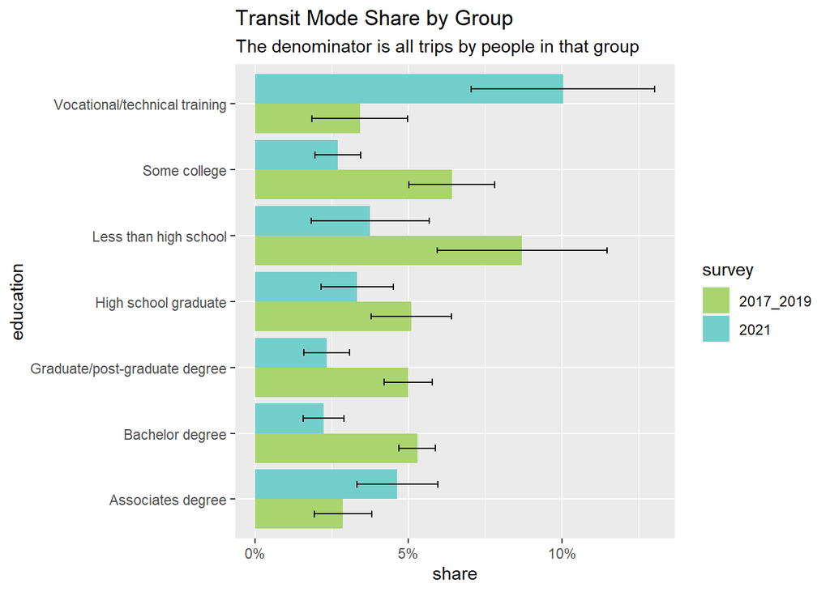

```
##        hhincome_detailed survey17_19 mode_simple17_19 count17_19 count_moe17_19
##  1:      $10,000-$24,999   2017_2019          Transit   83145.27      19943.642
##  2:    $100,000-$149,999   2017_2019          Transit   96717.79      15039.724
##  3:    $150,000-$199,999   2017_2019          Transit   74025.80      18149.123
##  4:    $200,000-$249,999   2017_2019          Transit   67917.99      28956.427
##  5:      $25,000-$34,999   2017_2019          Transit   52737.09      18441.755
##  6:     $250,000 or more   2017_2019          Transit   25714.00       8441.988
##  7:      $35,000-$49,999   2017_2019          Transit   45115.10      10185.673
##  8:      $50,000-$74,999   2017_2019          Transit   96973.08      19648.196
##  9:      $75,000-$99,999   2017_2019          Transit   64943.96      14796.191
## 10: Prefer not to answer   2017_2019          Transit   50316.83      14897.109
## 11:        Under $10,000   2017_2019          Transit   62956.79      18928.769
##     share17_19 share_moe17_19 sample_size17_19 survey21 mode_simple21
##  1: 0.09062147    0.021470270              611     2021       Transit
##  2: 0.03644299    0.005831496             1620     2021       Transit
```

[output cut: 21 more lines]

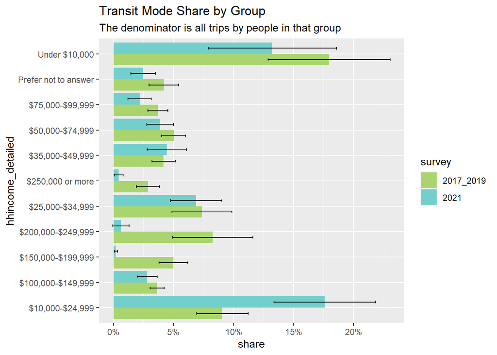

```
##            age survey17_19 mode_simple17_19 count17_19 count_moe17_19
## 1: 18-24 years   2017_2019          Transit   88884.13      27566.294
## 2: 25-34 years   2017_2019          Transit  199627.55      23470.078
## 3: 35-44 years   2017_2019          Transit  122582.08      20165.872
## 4: 45-54 years   2017_2019          Transit  144187.52      30709.527
## 5: 55-64 years   2017_2019          Transit   69931.69      13119.901
## 6: 65-74 years   2017_2019          Transit   69978.63      23779.975
## 7: 75-84 years   2017_2019          Transit   13907.16       5710.998
##    share17_19 share_moe17_19 sample_size17_19 survey21 mode_simple21    count21
## 1: 0.11533531    0.033000504              771     2021       Transit  40745.617
## 2: 0.07152340    0.008534411             3284     2021       Transit 100426.139
## 3: 0.04077579    0.006750046             1725     2021       Transit 101845.343
## 4: 0.05048944    0.010596348              918     2021       Transit  72008.655
## 5: 0.03427368    0.006550039              740     2021       Transit  81833.737
## 6: 0.03975578    0.013209513              368     2021       Transit  45619.704
## 7: 0.02639999    0.011055019              115     2021       Transit   5831.114
##    count_moe21    share21 share_moe21 sample_size21
## 1:   16680.811 0.03762427 0.015204984            34
## 2:   24646.002 0.03471710 0.008426599            95
## 3:   27666.866 0.03622855 0.009678865            83
## 4:   20247.851 0.03381454 0.009416258            89
## 5:   23913.933 0.03521850 0.010139305            81
## 6:   18296.497 0.02239019 0.008883168            43
## 7:    2909.075 0.01213933 0.006125945            12
```

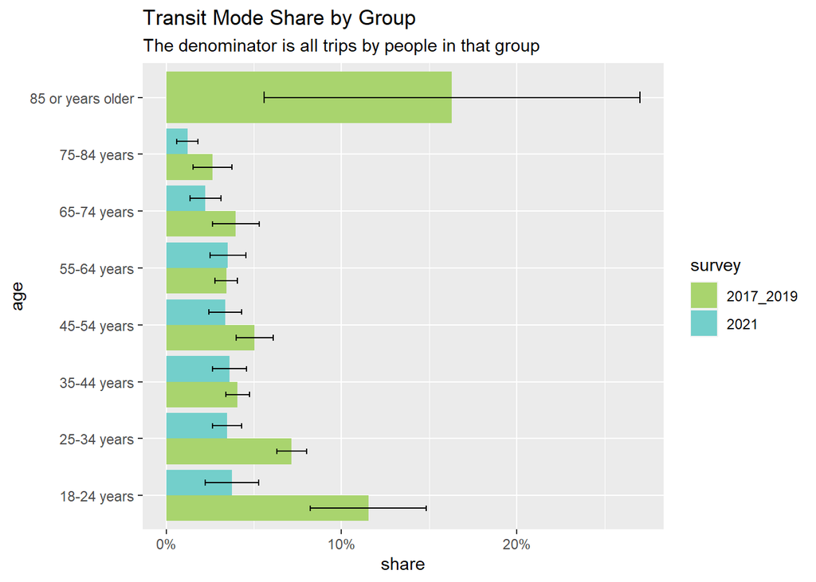

```
##    age_category survey17_19 mode_simple17_19 count17_19 count_moe17_19
## 1:  18-64 years   2017_2019          Transit  625212.96       53104.24
## 2:    65 years+   2017_2019          Transit   95350.73       25644.00
##    share17_19 share_moe17_19 sample_size17_19 survey21 mode_simple21   count21
## 1: 0.05453625     0.00460491             7438     2021       Transit 396859.49
## 2: 0.04044800     0.01067682              517     2021       Transit  51450.82
##    count_moe21    share21 share_moe21 sample_size21
## 1:    51004.40 0.03530788 0.004504241           382
## 2:    18522.65 0.01947398 0.006951764            55
```

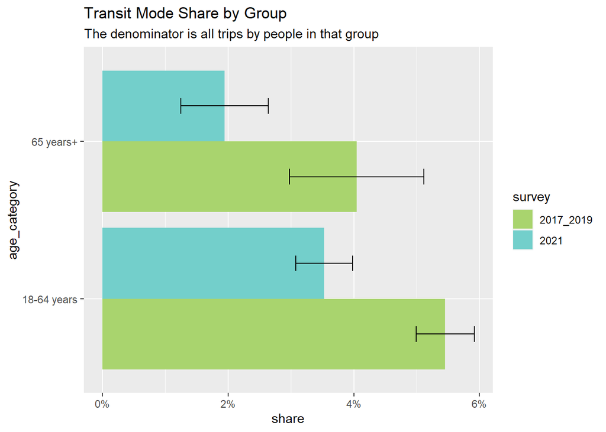

```
##       race_category survey17_19 mode_simple17_19 count17_19 count_moe17_19
## 1: African American   2017_2019          Transit   67514.36       19428.41
## 2:            Asian   2017_2019          Transit   73969.53       11992.11
## 3:         Hispanic   2017_2019          Transit   35852.36       12528.39
## 4:          Missing   2017_2019          Transit   64276.76       20652.19
## 5:            Other   2017_2019          Transit   54401.62       15325.36
## 6:       White Only   2017_2019          Transit  424549.06       46329.46
##    share17_19 share_moe17_19 sample_size17_19 survey21 mode_simple21   count21
## 1: 0.12780071     0.03513336              217     2021       Transit  43565.61
## 2: 0.06956350     0.01174372             1289     2021       Transit 110346.20
## 3: 0.05441043     0.01870358              424     2021       Transit  19912.23
## 4: 0.04210012     0.01354461              363     2021       Transit  14154.36
## 5: 0.05342887     0.01507557              387     2021       Transit  20656.07
## 6: 0.04703608     0.00505942             5275     2021       Transit 239675.84
##    count_moe21    share21 share_moe21 sample_size21
## 1:   15395.804 0.06230673 0.021664399            44
## 2:   28649.533 0.06379261 0.016038586            86
## 3:   11070.594 0.02166631 0.011963668            21
## 4:    8147.226 0.02003962 0.011493135            26
## 5:    7855.307 0.03699434 0.014124734            39
## 6:   40723.921 0.02585694 0.004360521           221
```

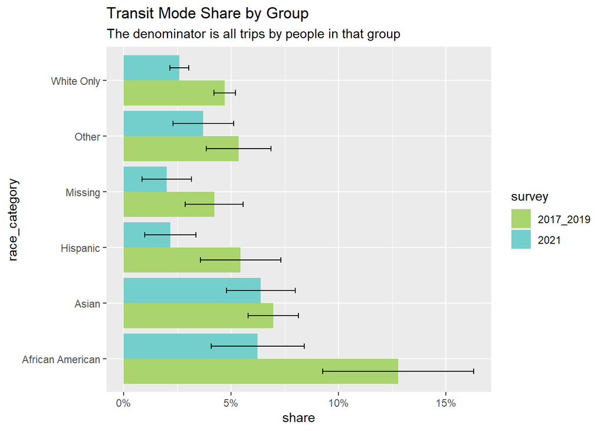

```
##                                         race_eth_broad survey17_19
## 1:                     Asian only, non-Hispanic/Latinx   2017_2019
## 2: Black or African American only, non-Hispanic/Latinx   2017_2019
## 3:                                  Hispanic or Latinx   2017_2019
## 4:                                           No Answer   2017_2019
## 5:       Other race, including multi-race non-Hispanic   2017_2019
## 6:                     White only, non-Hispanic/Latinx   2017_2019
##    mode_simple17_19 count17_19 count_moe17_19 share17_19 share_moe17_19
## 1:          Transit   66372.42       11598.52 0.06743586     0.01226854
## 2:          Transit   64559.83       19104.93 0.13882276     0.03937145
## 3:          Transit   50497.60       15802.72 0.06828210     0.02078216
## 4:          Transit   64276.76       20652.19 0.04210012     0.01354461
## 5:          Transit   50308.01       12801.42 0.04658490     0.01201037
## 6:          Transit  424549.06       46329.46 0.04703608     0.00505942
##    sample_size17_19 survey21 mode_simple21   count21 count_moe21    share21
## 1:             1158     2021       Transit 108159.56   28612.681 0.06715925
## 2:              180     2021       Transit  42114.95   15334.609 0.06590662
## 3:              491     2021       Transit  24494.79   12180.310 0.02474983
## 4:              363     2021       Transit  14154.36    8147.226 0.02003962
## 5:              488     2021       Transit  19710.80    6325.051 0.02954360
## 6:             5275     2021       Transit 239675.84   40723.921 0.02585694
##    share_moe21 sample_size21
## 1: 0.017164282            80
## 2: 0.023565723            41
## 3: 0.012210640            24
## 4: 0.011493135            26
## 5: 0.009668573            45
## 6: 0.004360521           221
```

[6 more figures not shown]

```r
groupings<- other_vars
for(g in groupings){

cat_name<- eval(g)

transit_summs_2017_2019<-hhts_count(transit_data_17_19, group_vars=c(g,'mode_simple'), spec_wgt='trip_weight_2017_2019_v2021_adult')%>%
  filter(cat_name!='Total') %>%
  filter(mode_simple=='Transit')
transit_summs_2021<-hhts_count(transit_data_21, group_vars=c(g,'mode_simple'), spec_wgt='trip_weight_2021_ABS_Panel_adult')%>%
  filter(cat_name!='Total') %>%
  filter(mode_simple=='Transit')

transit_summs<-merge(transit_summs_2017_2019, transit_summs_2021, by=cat_name, suffixes=c('17_19', '21'))
write.csv(transit_summs, paste('transit_mode_share_', cat_name, '.csv'))
print(transit_summs)
transit_summs_long<- rbind(transit_summs_2017_2019, transit_summs_2021)

p<-ggplot(transit_summs_long, aes(x=get(g), y=share, fill=survey))+geom_bar(stat='identity',position=position_dodge())+xlab(cat_name)+ggtitle('Transit Mode Share by Group', 'The denominator is all trips by people in that group')+scale_fill_discrete_psrc('psrc_light')+
  geom_errorbar(aes(ymin=share-share_moe, ymax=share+share_moe), width=.2,
                 position=position_dodge(.9)) +coord_flip() +scale_y_continuous(labels=scales::percent)
print(p)
}
```

Group variables into meaningful categories and redo analysis

```r
transit_data_17_19<-transit_data_17_19%>%mutate(NoVehicles=ifelse(vehicle_count=='0 (no vehicles)', 'No Vehicles', "Has Vehicles"))%>%
  mutate(hhsize_simple=case_when(hhsize== '4 people' ~'4 or more people',                                                                     hhsize== '5 people' ~'4 or more people',
                                  hhsize== '6 people' ~'4 or more people',
                                  hhsize== '7 people' ~'4 or more people',
                                  hhsize== '8 people' ~'4 or more people',
                                  hhsize== '12 people' ~'4 or more people',
                                  TRUE ~ hhsize))%>%
  mutate(hhincome_100= case_when(hhincome_broad=='$100,000-$199,000' ~ '$100,000 or more',
                                 hhincome_broad=='$200,000 or more' ~ '$100,000 or more',
                                 TRUE~hhincome_broad))%>%
  mutate(edu_simple= case_when(education=='Bachelor degree' ~ 'Bachelors or higher',
                               education=='Graduate/Post-graduate degree' ~ 'Bachelors or higher',
                               TRUE ~ 'Less than Bachelors degree'))%>%
  mutate(age_grp= case_when(age=='75-84 years' ~ '75 years or older',
                            age == '85 or years older' ~ '75 years or older',
                            TRUE ~ age))%>%
  mutate(gender_grp= case_when(gender == 'Prefer not to answer' ~ 'Non-binary, another, prefer not to answer',
                            gender=='Not listed here/prefer not to answer' ~ 'Non-binary, another, not listed/prefer not to answer',
                            gender=='Non-Binary'~ 'Non-binary, another, not listed/prefer not to answer',
                            gender=='Another'~ 'Non-binary, another, not listed/prefer not to answer',
                            TRUE ~ gender))%>%
  mutate(work_purpose=ifelse(dest_purpose_cat=='Work', 'Work', 'Not Work'))%>%
    mutate(race_short= str_extract(race_eth_broad,  "^[^ ]+"))%>%
  mutate(employed = case_when(employment== 'Employed full time (35+ hours/week, paid)' ~ 'Employed',
                              employment== "Employed part time (fewer than 35 hours/week, paid)"  ~ 'Employed',
                              employment=="Self-employed"~ 'Employed',
                              TRUE ~ 'Not Employed'))

transit_data_21<-transit_data_21%>%mutate(NoVehicles=ifelse(vehicle_count=='0 (no vehicles)', 'No Vehicles', "Has Vehicles"))%>%
  mutate(hhsize_simple=case_when(hhsize== '4 people' ~'4 or more people',                                                                    hhsize== '5 people' ~'4 or more people',
                                 hhsize== '6 people' ~'4 or more people',
                                 hhsize== '7 people' ~'4 or more people',
                                 hhsize== '8 people' ~'4 or more people',
                                 hhsize== '12 people' ~'4 or more people',
                                 TRUE ~ hhsize)) %>%
  mutate(hhincome_100= case_when(hhincome_broad=='$100,000-$199,000' ~ '$100,000 or more',
                                 hhincome_broad=='$200,000 or more' ~ '$100,000 or more',
                                 TRUE~hhincome_broad))%>%
  mutate(edu_simple= case_when(education=='Bachelor degree' ~ 'Bachelors or higher',
                               education=='Graduate/Post-graduate degree' ~ 'Bachelors or higher',
                               TRUE ~ 'Less than Bachelors degree'))%>%
  mutate(age_grp= case_when(age=='75-84 years' ~ '75 years or older',
                            age == '85 or years older' ~ '75 years or older',
                            TRUE ~ age))%>%
  mutate(gender_grp= case_when(gender == 'Prefer not to answer' ~ 'Non-binary, another, prefer not to answer',
                            gender=='Not listed here/prefer not to answer' ~ 'Non-binary, another, not listed/prefer not to answer',
                            gender=='Non-Binary'~ 'Non-binary, another, not listed/prefer not to answer',
                            gender=='Another'~ 'Non-binary, another, not listed/prefer not to answer',
                            TRUE ~ gender))%>%
  mutate(work_purpose=ifelse(dest_purpose_cat=='Work', 'Work', 'Not Work'))%>%mutate(employed = case_when(employment== 'Employed full time (35+ hours/week, paid)' ~ 'Employed',
                              employment== "Employed part time (fewer than 35 hours/week, paid)"  ~ 'Employed',
                              employment=="Self-employed"~ 'Employed',
                              TRUE~ 'Not Employed'))


simple_groupings<-c('race_eth_broad'='Race/Ethnicity','hhincome_100_f'='Household Income','edu_simple'= 'Education Level', 'hhsize_simple'= 'Household Size','NoVehicles'= 'Household Vehicles', 'student'="Student Status",'work_purpose'="Trip Purpose", 'employed'= "Person Employment Status")
```

```r
# bunch of ordering and recoding

transit_data_17_19$hhincome_100_f=factor(transit_data_17_19$hhincome_100, levels=c("Prefer not to answer",  "$100,000 or more","$75,000-$99,999", "$50,000-$74,999" ,"$25,000-$49,999" , "Under $25,000"  ))

transit_data_21$hhincome_100_f=factor(transit_data_21$hhincome_100, levels=c("Prefer not to answer",  "$100,000 or more","$75,000-$99,999", "$50,000-$74,999" ,"$25,000-$49,999" , "Under $25,000"  ))
```